# CEE218X Assignment 3

## 3.1

*Select one (or at most, two) outcomes of interest that can be measured at the CBG, tract, or ZCTA level in the Bay Area. They must be continuous variables (like % of households in poverty) at this scale of analysis. At least one of the outcomes must also be available in the PUMS data at the individual or household level, so that one of your analyses can make use of PUMS data specifically.*

### Household income <> Education attainment

Let’s investigate the relationship between income and education attainment at census tract level. According to [QS education report](https://www.qs.com/what-effect-does-education-level-have-on-wealth/), the relationship between education and income is strong, those with more education have better chances to earn higher incomes. To evaluate, I use ACS 5-year data in 2018 to take a detailed look for the bay area.

```r
library(tidyverse)
library(sf)
library(tigris)
library(leaflet)
library(censusapi)
library(kableExtra)
library(plotly)
library(tidycensus)
census_api_key("c8aa67e4086b4b5ce3a8717f59faa9a28f611dab")
Sys.setenv(CENSUS_KEY="c8aa67e4086b4b5ce3a8717f59faa9a28f611dab")

bay_income_college_tract <-
  getCensus(
    name = "acs/acs5",
    vintage = 2018,
    region = "tract:*",
    regionin = "state:06+county:001,013,041,055,075,081,085,095,097",
    vars = c(
      "B19001A_001E",
      "B19001_001E",
      "B19001_014E",
      "B19001_015E",
      "B19001_016E",
      "B19001_017E",
      "B14001_001E",
      "B14004_001E",
      "B14004_010E",
      "B14006_001E",
      "B14006_002E",
      "B14001_008E",
      "B14001_009E",
      "B17007_002E",
      "B17007_001E",
      "B15001_001E",
      "B15001_009E",
      "B15001_010E",
      "B15001_003E",
      "B15003_001E",
      "B15003_022E",
      "B15003_023E",
      "B15003_024E",
      "B15003_025E"
    )
  ) %>%
  transmute(
    tract = paste0(state, county, tract),
    perc_college = (B15003_022E + B15003_023E + B15003_024E + B15003_025E) / B15003_001E,
    perc_poverty = B17007_002E / B17007_001E,
    perc_over100k = (B19001_014E + B19001_015E + B19001_016E + B19001_017E) / B19001_001E
  ) %>%
  filter(
    !is.na(perc_college),
    !is.na(perc_over100k)
  )
```

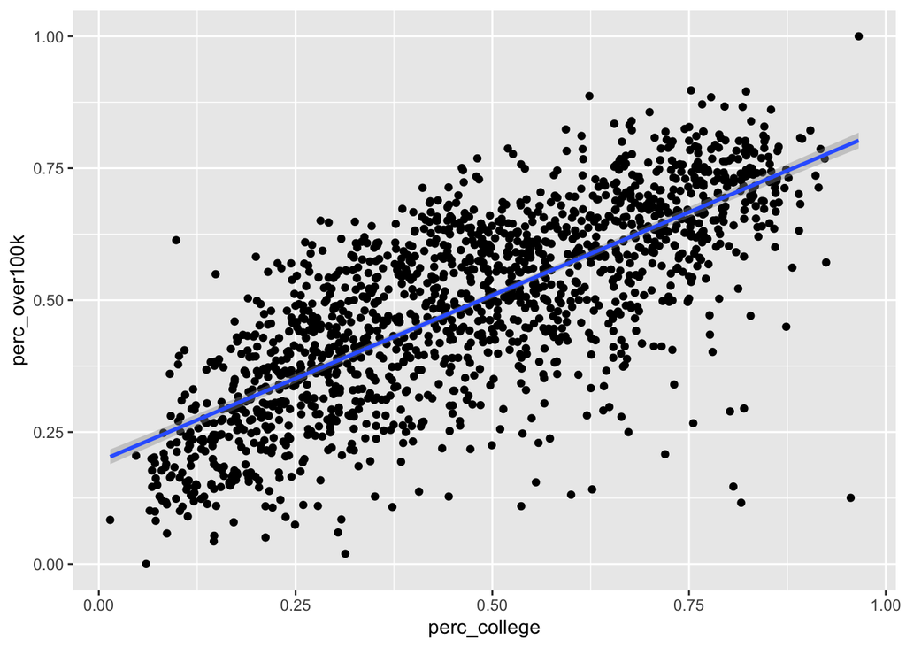

```r
ggplot(
  data = bay_income_college_tract,
  aes(
      x = perc_college,
      y = perc_over100k
    )
) +
  geom_point() +
  geom_smooth(method = "lm")
```

```r
model <- lm(perc_over100k ~ perc_college, bay_income_college_tract)
summary(model)
```

```
##
## Call:
## lm(formula = perc_over100k ~ perc_college, data = bay_income_college_tract)
##
## Residuals:
##      Min       1Q   Median       3Q      Max
## -0.67052 -0.07260  0.00471  0.08415  0.35753
##
## Coefficients:
##              Estimate Std. Error t value Pr(>|t|)
## (Intercept)  0.194094   0.007292   26.62   <2e-16 ***
## perc_college 0.629953   0.014085   44.73   <2e-16 ***
## ---
## Signif. codes:  0 '***' 0.001 '**' 0.01 '*' 0.05 '.' 0.1 ' ' 1
##
## Residual standard error: 0.1209 on 1575 degrees of freedom
## Multiple R-squared:  0.5595, Adjusted R-squared:  0.5592
## F-statistic:  2000 on 1 and 1575 DF,  p-value: < 2.2e-16
```

Here is the outcome of linear regression by R. I choose x-axis to be the percentage of people with a college degree or above, including bachelor, master, professional school and doctorate degree in the population 25 years and over, and y-axis to be the percentage of people with income higher than 100k, we could see a quite strong correlation between income level as R-squared is around 0.55 and P-value is less than 0.01. We could infer that variation in the percentage of people with a college degree or above might explain 55% of the variation in percentage of households with more than 100k annual income. In conclusion, a higher percentage of people 25 years older with a college degree would often lead to a higher percentage of high household income level.

## 3.2

*Perform an individual or household level multiple regression analysis (with PUMS data for PUMAS in the Bay Area) using one of your outcomes of interest as the dependent variable and at least two independent variables (like language ability or commute time), which should be chosen based on some brief open-ended exploration of academic papers, news articles, or personal anecdotes that suggest a statistical relationship may be found between the independent and dependent variables.*

### Household income <> (Household language & Internet access)

Now we can dive deeper and investigate the relationship between income and household language as well as access to Internet in the bay area. According to [Pew research](https://www.pewresearch.org/fact-tank/2019/05/07/digital-divide-persists-even-as-lower-income-americans-make-gains-in-tech-adoption/), digital divides persist between low-income and high-income Americans, one big divide is the access to high-speed Internet. And an [HBR study](https://hbr.org/2013/11/countries-with-better-english-have-better-economies) reveals that better English overall will bring individuals better economic status. To evaluate, I use PUMS data 2018 in the bay area at the household level.

```r
pums_vars_2018 <-
  pums_variables %>%
  filter(year == 2018, survey == "acs5")

pums_vars_2018_distinct_hh <-
  pums_vars_2018 %>%
  distinct(var_code, var_label, data_type, level) %>%
  filter(level == "housing")

ca_pums <- get_pums(
  variables = c(
    "PUMA",
    "NP",
    "RAC1P",
    "HINCP",
    "HHL",
    "ACCESS"
  ),
  state = "CA",
  year = 2018,
  survey = "acs5",
  recode = T
)

ca_pumas <-
  pumas("CA", cb = T, progress_bar = F)

bay_county_names <-
  c(
    "Alameda",
    "Contra Costa",
    "Marin",
    "Napa",
    "San Francisco",
    "San Mateo",
    "Santa Clara",
    "Solano",
    "Sonoma"
  )

bay_counties <-
  counties("CA", cb = T, progress_bar = F) %>%
  filter(NAME %in% bay_county_names)

bay_pumas <-
  ca_pumas %>%
  st_centroid() %>%
  .[bay_counties, ] %>%
  st_set_geometry(NULL) %>%
  left_join(ca_pumas %>% select(GEOID10)) %>%
  st_as_sf()

bay_pums <-
  ca_pums %>%
  filter(PUMA %in% bay_pumas$PUMACE10)
```

```r
bay_pums_regression <-
  bay_pums %>%
  filter(SPORDER == 1) %>%
  mutate(
    white = ifelse(
      RAC1P_label == "White alone",
      1,
      0
    ),
    English = ifelse(
      HHL_label == "English only",
      1,
      0
    ),
    over100k = ifelse(
      HINCP > 100000,
      1,
      0
    ),
    HouseholdIncome = HINCP,
    InternetAccess = ifelse(
      ACCESS_label == "Yes, by paying a cell phone company or Internet service provider",
      1,
      0
    )
  )
```

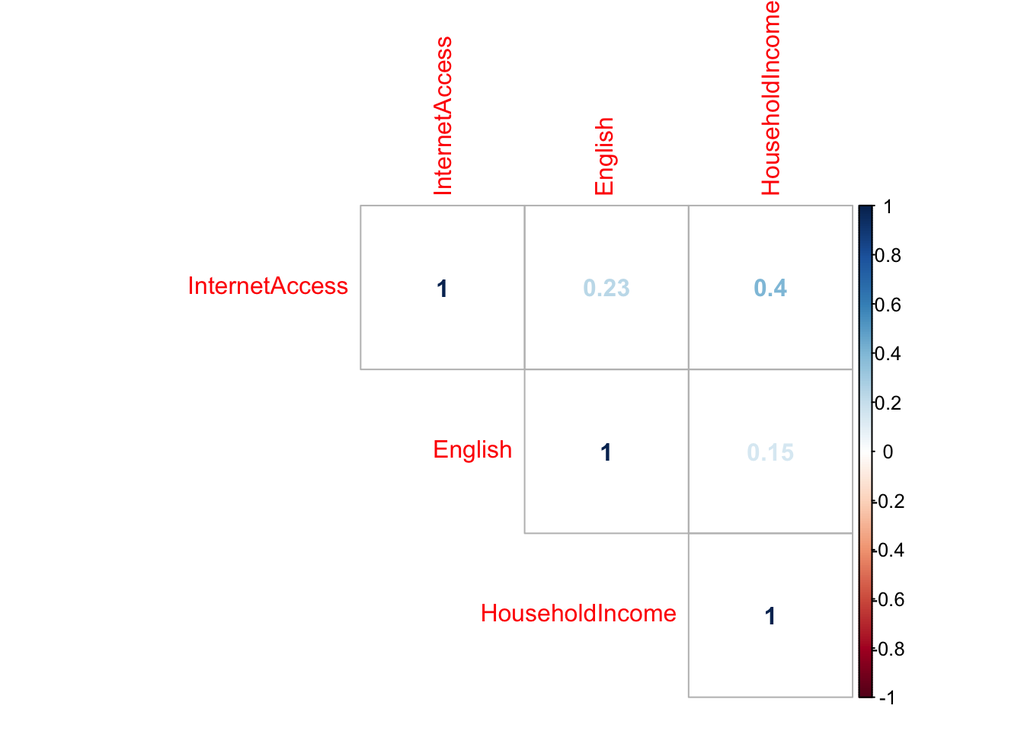

```r
library(corrplot)

correlationplot <- bay_pums_regression %>%
  select(
    InternetAccess,
    English,
    HouseholdIncome
  ) %>%
  cor()

corrplot(
  correlationplot,
  method = "number",
  type = "upper"
)
```

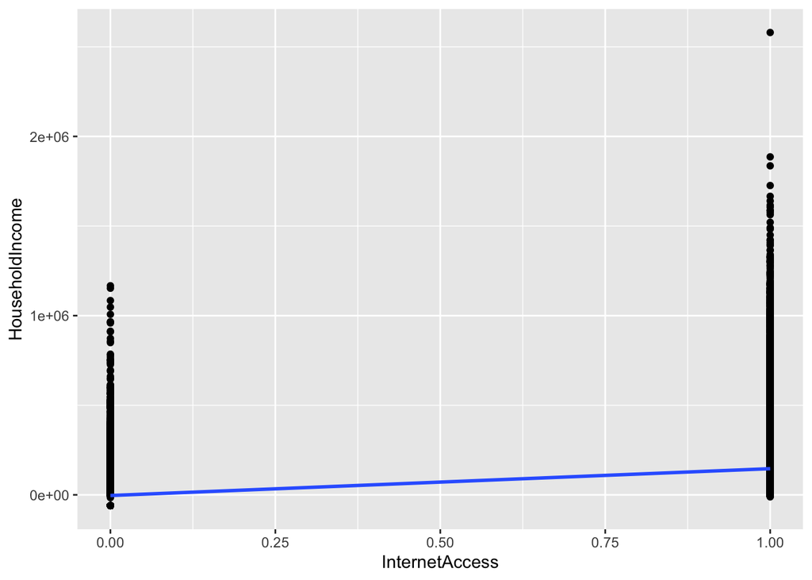

```r
ggplot(
  data = bay_pums_regression,
  aes(
      x = InternetAccess,
      y = HouseholdIncome
    )
) +
  geom_point() +
  geom_smooth(method = "lm")
```

```r
model_pums <- lm(HouseholdIncome ~ InternetAccess, bay_pums_regression, weights = WGTP)
summary(model_pums)
```

```
##
## Call:
## lm(formula = HouseholdIncome ~ InternetAccess, data = bay_pums_regression,
##     weights = WGTP)
##
## Weighted Residuals:
##      Min       1Q   Median       3Q      Max
## -1835070  -293063   -76239   118076 11440951
##
## Coefficients:
##                Estimate Std. Error t value Pr(>|t|)
## (Intercept)       51178       1061   48.23   <2e-16 ***
## InternetAccess    89603       1124   79.70   <2e-16 ***
## ---
## Signif. codes:  0 '***' 0.001 '**' 0.01 '*' 0.05 '.' 0.1 ' ' 1
##
## Residual standard error: 578200 on 138437 degrees of freedom
## Multiple R-squared:  0.04387,    Adjusted R-squared:  0.04386
## F-statistic:  6352 on 1 and 138437 DF,  p-value: < 2.2e-16
```

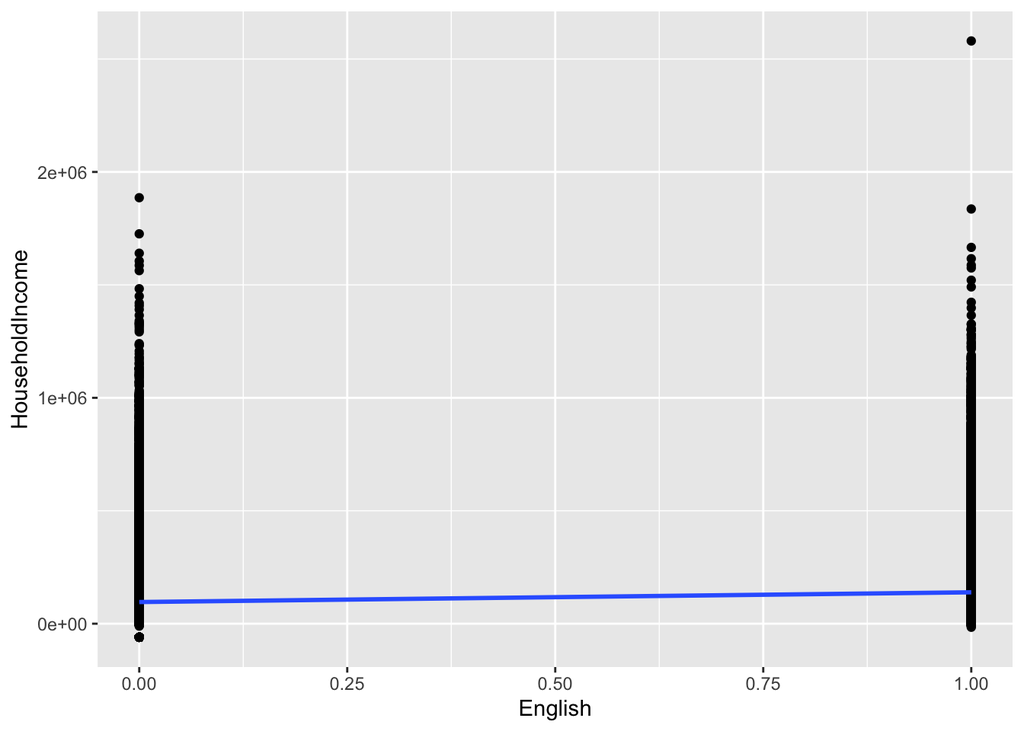

```r
ggplot(
  data = bay_pums_regression,
  aes(
      x = English,
      y = HouseholdIncome
    )
) +
  geom_point() +
  geom_smooth(method = "lm")
```

```r
model_pums <- lm(HouseholdIncome ~ English, bay_pums_regression, weights = WGTP)
summary(model_pums)
```

```
##
## Call:
## lm(formula = HouseholdIncome ~ English, data = bay_pums_regression,
##     weights = WGTP)
##
## Weighted Residuals:
##      Min       1Q   Median       3Q      Max
## -1658754  -311374   -78664   135288 11470947
##
## Coefficients:
##             Estimate Std. Error t value Pr(>|t|)
## (Intercept) 126477.9      546.6  231.39   <2e-16 ***
## English       7908.0      724.4   10.92   <2e-16 ***
## ---
## Signif. codes:  0 '***' 0.001 '**' 0.01 '*' 0.05 '.' 0.1 ' ' 1
##
## Residual standard error: 591100 on 138437 degrees of freedom
## Multiple R-squared:  0.0008601,  Adjusted R-squared:  0.0008528
## F-statistic: 119.2 on 1 and 138437 DF,  p-value: < 2.2e-16
```

```r
model_pums <- lm(HouseholdIncome ~ English+InternetAccess, bay_pums_regression, weights = WGTP)
summary(model_pums)
```

```
##
## Call:
## lm(formula = HouseholdIncome ~ English + InternetAccess, data = bay_pums_regression,
##     weights = WGTP)
##
## Weighted Residuals:
##      Min       1Q   Median       3Q      Max
## -1795215  -294084   -76766   118542 11425574
##
## Coefficients:
##                Estimate Std. Error t value Pr(>|t|)
## (Intercept)     46889.5     1132.9   41.39   <2e-16 ***
## English          7627.2      708.4   10.77   <2e-16 ***
## InternetAccess  89542.7     1123.8   79.68   <2e-16 ***
## ---
## Signif. codes:  0 '***' 0.001 '**' 0.01 '*' 0.05 '.' 0.1 ' ' 1
##
## Residual standard error: 578000 on 138436 degrees of freedom
## Multiple R-squared:  0.04467,    Adjusted R-squared:  0.04466
## F-statistic:  3237 on 2 and 138436 DF,  p-value: < 2.2e-16
```

Here I choose household language and access to Internet as independent variables, and household income as dependent variables.

- From the above plots we could see an English-speaking household tends to have a higher income. Specifically, all else being equal, an English-speaking household seems to be associated with $8k more income on average than a counterpart, which have an average household income of about $126k.
- For access to Internet, the differences are more significant, the household with Internet access seems to have $89k more income than a non-access household, whose average income is about $51k. The null hypothesis of no relationship between both independent variables and household income is rejected as the P value is almost 0 for household language as well as access to Internet.
- Specifically, in the outcomes of multi-regression analysis, we could see access to Internet plays a bigger factor in income compared with household language. In sum, the results from this multiple regression analysis ally with these findings in [Pew research](https://www.pewresearch.org/fact-tank/2019/05/07/digital-divide-persists-even-as-lower-income-americans-make-gains-in-tech-adoption/) and [HBR study](https://hbr.org/2013/11/countries-with-better-english-have-better-economies).

## 3.3

*Perform at least one additional multiple regression analysis at the CBG, tract, or ZCTA level in the Bay Area, at which you may choose to use a similar outcome as the first analysis or a different one. Again, select at least two independent variables. Both independent and dependent variables can now come from other datasets besides the ACS, as long as they match the geographic scale of analysis.*

### Household income <> (STEM majors & Asian population)

According to a [study](https://cmhc.utexas.edu/modelminority.html#what) from University of Texas, Asian population are sometimes perceived to achieve a higher degree of socioeconomic success than the population average, thus serving as a reference group to outgroups as so-called “model minority”. And researchers from Georgetown publish in a [paper](https://1gyhoq479ufd3yna29x7ubjn-wpengine.netdna-ssl.com/wp-content/uploads/The-Economic-Value-of-College-Majors-Full-Report-web-FINAL.pdf) claiming that STEM (science, technology, engineering, and mathematics) are among the highest paying, leading to average annual wages of $37,000 or more at the entry level and an average of $65,000 or more annually over the course of a recipient’s career.

In this part, I’ll look at the relationship between household income and Asian population as well as STEM majors in the bay area. To evaluate, I’ll use ACS 5-year data in 2018 at census tract level.

```r
bay_income_stem_asia_tract <-
  getCensus(
    name = "acs/acs5",
    vintage = 2018,
    region = "tract:*",
    regionin = "state:06+county:001,013,041,055,075,081,085,095,097",
    vars = c(
      "B19001A_001E",
      "B19001_001E",
      "B19001_014E",
      "B19001_015E",
      "B19001_016E",
      "B19001_017E",
      "B14001_001E",
      "B14004_001E",
      "B14004_010E",
      "B14006_001E",
      "B14006_002E",
      "B14001_008E",
      "B14001_009E",
      "B17007_002E",
      "B17007_001E",
      "B15001_001E",
      "B15001_009E",
      "B15001_010E",
      "B15001_003E",
      "B15003_001E",
      "B15003_022E",
      "B15003_023E",
      "B15003_024E",
      "B15003_025E",
      "B19001D_001E",
      "B15011_001E",
      "B15011_004E",
      "B15011_005E",
      "B15011_010E",
      "B15011_011E",
      "B15011_023E",
      "B15011_024E",
      "B15011_029E",
      "B15011_030E"
    )
  ) %>%
  transmute(
    tract = paste0(state, county, tract),
    perc_stem = (B15011_004E + B15011_005E + B15011_010E + B15011_011E + B15011_023E + B15011_024E + B15011_029E + B15011_030E) / B15011_001E,
    perc_asia = B19001D_001E / B19001_001E,
    perc_over100k = (B19001_014E + B19001_015E + B19001_016E + B19001_017E) / B19001_001E
  ) %>%
  filter(
    !is.na(perc_stem),
    !is.na(perc_asia),
    !is.na(perc_over100k)
  )
```

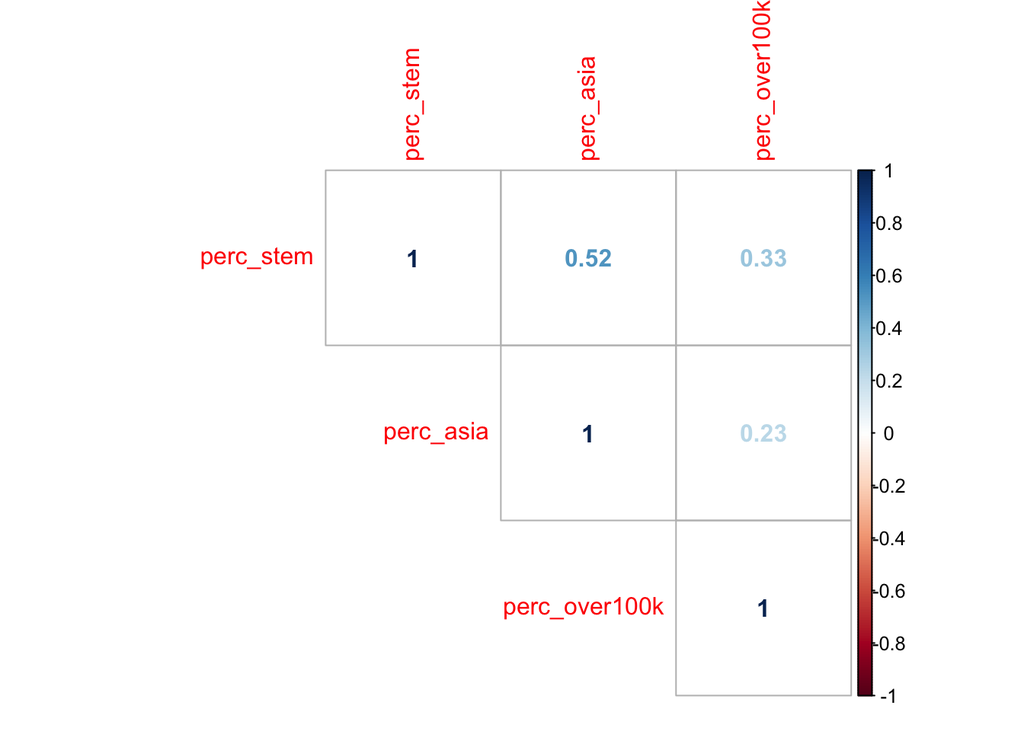

```r
library(corrplot)

correlationplot <- bay_income_stem_asia_tract %>%
  select(
    perc_stem,
    perc_asia,
    perc_over100k
  ) %>%
  cor()

corrplot(
  correlationplot,
  method = "number",
  type = "upper"
)
```

Here is a correlation plot indicating the relationship between the three variables: the percentage of people with STEM majors in their Bachelor’s degree, the percentage of Asian population, and the percentage of people with more than 100k annual income. At first glance, it seems the percentage of stem is quite correlated with high income and Asian population in particular. Let’s take a look at the regression analysis:

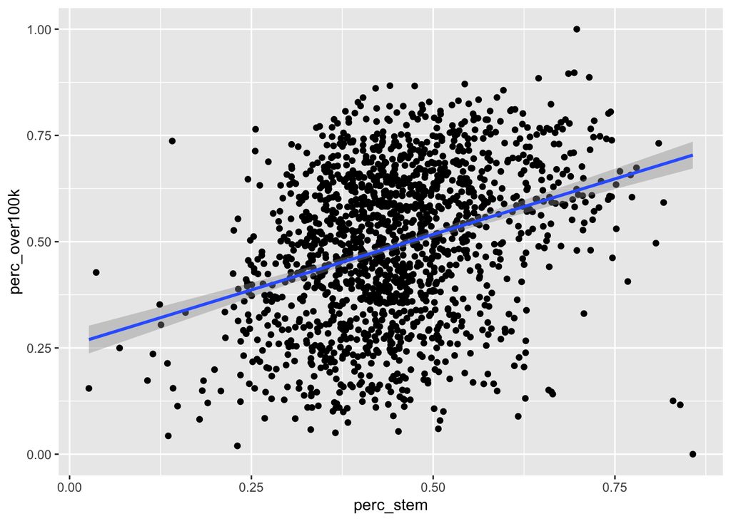

```r
ggplot(
  data = bay_income_stem_asia_tract,
  aes(
      x = perc_stem,
      y = perc_over100k
    )
) +
  geom_point() +
  geom_smooth(method = "lm")
```

```r
summary(lm(perc_over100k ~ perc_stem, bay_income_stem_asia_tract))
```

```
##
## Call:
## lm(formula = perc_over100k ~ perc_stem, data = bay_income_stem_asia_tract)
##
## Residuals:
##      Min       1Q   Median       3Q      Max
## -0.70375 -0.11877  0.01062  0.12763  0.40723
##
## Coefficients:
##             Estimate Std. Error t value Pr(>|t|)
## (Intercept)  0.25584    0.01761   14.53   <2e-16 ***
## perc_stem    0.52256    0.03803   13.74   <2e-16 ***
## ---
## Signif. codes:  0 '***' 0.001 '**' 0.01 '*' 0.05 '.' 0.1 ' ' 1
##
## Residual standard error: 0.1721 on 1575 degrees of freedom
## Multiple R-squared:  0.107,  Adjusted R-squared:  0.1065
## F-statistic: 188.8 on 1 and 1575 DF,  p-value: < 2.2e-16
```

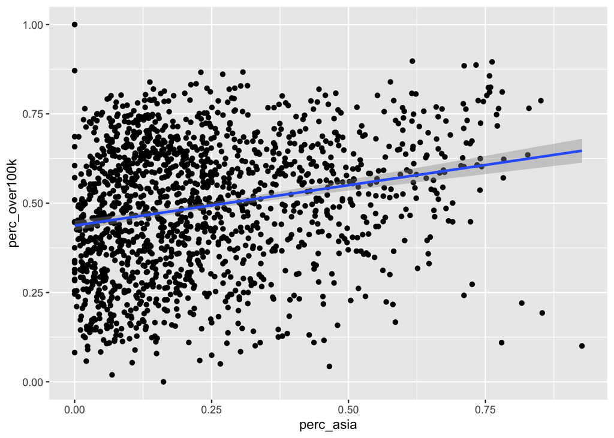

```r
ggplot(
  data = bay_income_stem_asia_tract,
  aes(
      x = perc_asia,
      y = perc_over100k
    )
) +
  geom_point() +
  geom_smooth(method = "lm")
```

```r
summary(lm(perc_over100k ~ perc_asia, bay_income_stem_asia_tract))
```

```
##
## Call:
## lm(formula = perc_over100k ~ perc_asia, data = bay_income_stem_asia_tract)
##
## Residuals:
##      Min       1Q   Median       3Q      Max
## -0.54635 -0.12897  0.01088  0.13759  0.56274
##
## Coefficients:
##             Estimate Std. Error t value Pr(>|t|)
## (Intercept) 0.437264   0.007162   61.05   <2e-16 ***
## perc_asia   0.226144   0.023829    9.49   <2e-16 ***
## ---
## Signif. codes:  0 '***' 0.001 '**' 0.01 '*' 0.05 '.' 0.1 ' ' 1
##
## Residual standard error: 0.1772 on 1575 degrees of freedom
## Multiple R-squared:  0.05409,    Adjusted R-squared:  0.05349
## F-statistic: 90.07 on 1 and 1575 DF,  p-value: < 2.2e-16
```

```r
summary(lm(perc_over100k ~ perc_asia + perc_stem, bay_income_stem_asia_tract))
```

```
##
## Call:
## lm(formula = perc_over100k ~ perc_asia + perc_stem, data = bay_income_stem_asia_tract)
##
## Residuals:
##      Min       1Q   Median       3Q      Max
## -0.66890 -0.12047  0.00868  0.13046  0.41657
##
## Coefficients:
##             Estimate Std. Error t value Pr(>|t|)
## (Intercept)  0.26823    0.01804  14.872  < 2e-16 ***
## perc_asia    0.08225    0.02709   3.036  0.00244 **
## perc_stem    0.45189    0.04450  10.154  < 2e-16 ***
## ---
## Signif. codes:  0 '***' 0.001 '**' 0.01 '*' 0.05 '.' 0.1 ' ' 1
##
## Residual standard error: 0.1717 on 1574 degrees of freedom
## Multiple R-squared:  0.1122, Adjusted R-squared:  0.1111
## F-statistic:  99.5 on 2 and 1574 DF,  p-value: < 2.2e-16
```

Now I choose the percentage of people majoring in STEM fields in their bachelor’s degree and percentage of Asian population as independent variables, we will use the percent of households earns more than $100k in one tract as dependent variables and conduct several regression analysis, the above tables show detailed results.

- From the plot we could see a higher percentage of STEM graduates will lead to a higher percentage of high income households, as the p-value is small enough to reject null hypothesis between these 2 variables. The R-squared for around 10%, we could infer that variation in STEM majors might explain 10% of the variation in percentage of households with more than 100k annual income.
- We also find a higher percentage of Asian population in a census tract could potentially indicate a higher percentage of households with more than 100k annual income, since the p-value is also small enough to reject null hypothesis. Compared with percentage of STEM grads, the R-squard between Asian population and household income is smaller.
- There’s a high correlation between Asian population and STEM major according to the correlation plot.
- In sum, the results from this multiple regression analysis ally with findings in the [Texas study](https://cmhc.utexas.edu/modelminority.html#what) and [Georgetown](https://1gyhoq479ufd3yna29x7ubjn-wpengine.netdna-ssl.com/wp-content/uploads/The-Economic-Value-of-College-Majors-Full-Report-web-FINAL.pdf).